# Assignment 2 - Logistic Regression

Author

Aziz Al Mezraani - ITAO 40420 - Machine Learning

Published

November 8, 2024

# Assignment 2

For this analysis we will be using churn data. The dataset is stored as `churn_data.rda` which can be loaded in by running the below command if the file is located in your working directory or else by accessing the file through file->open file

```r
load("churn_data.rda") # Load churn dataset

library(ggplot2)
library(reshape)
library(glmnet)
library(plotmo)
```

We can view a summary of this dataset by running `summary()`:

```r
summary(churn_data)
```

```
    gender          SeniorCitizen      Partner           Dependents
 Length:7032        Min.   :0.0000   Length:7032        Length:7032
 Class :character   1st Qu.:0.0000   Class :character   Class :character
 Mode  :character   Median :0.0000   Mode  :character   Mode  :character
                    Mean   :0.1624
                    3rd Qu.:0.0000
                    Max.   :1.0000
     tenure      PhoneService       MultipleLines      InternetService
 Min.   : 1.00   Length:7032        Length:7032        Length:7032
 1st Qu.: 9.00   Class :character   Class :character   Class :character
 Median :29.00   Mode  :character   Mode  :character   Mode  :character
 Mean   :32.42
 3rd Qu.:55.00
 Max.   :72.00
 OnlineSecurity     OnlineBackup       DeviceProtection   TechSupport
 Length:7032        Length:7032        Length:7032        Length:7032
 Class :character   Class :character   Class :character   Class :character
 Mode  :character   Mode  :character   Mode  :character   Mode  :character



 StreamingTV        StreamingMovies      Contract         PaperlessBilling
 Length:7032        Length:7032        Length:7032        Length:7032
 Class :character   Class :character   Class :character   Class :character
 Mode  :character   Mode  :character   Mode  :character   Mode  :character



 PaymentMethod      MonthlyCharges    TotalCharges        Churn
 Length:7032        Min.   : 18.25   Min.   :  18.8   Min.   :0.0000
 Class :character   1st Qu.: 35.59   1st Qu.: 401.4   1st Qu.:0.0000
 Mode  :character   Median : 70.35   Median :1397.5   Median :0.0000
                    Mean   : 64.80   Mean   :2283.3   Mean   :0.2658
                    3rd Qu.: 89.86   3rd Qu.:3794.7   3rd Qu.:1.0000
                    Max.   :118.75   Max.   :8684.8   Max.   :1.0000
```

The variables we have are:

- Gender - Whether the customer is a male or a female
- SeniorCitizen - Whether the customer is a senior citizen or not (1,0)
- Partner - Whether the customer has a partner or nor (Yes, No)
- Dependents - Whether the customer has dependents or not (Yes, No)
- tenure - Number of months the customer has stayed with the company
- PhoneService - Whether the customer has a phone service of no (Yes, No)
- MultipleLines - Whether the customer has multiple lines or not (Yes, No, No phone service)
- InternetService - Customer’s internet service provider (DSL, Fiber optic, No)
- OnlineSecurity - Whether the customer has online security or not (Yes, No, No internet service)
- OnlineBackup - Whether the customer has online backup or not (Yes, No, No internet service)
- DeviceProtection - Whether the customer has tech support or not (Yes, No, No internet service)
- StreamingTV - Whether the customer has streaming TV or not (Yes, No, No internet service)
- StreamingMovies - Whether the customer has streaming movies or not (Yes, No, No internet service)
- Contract - The contract term of the customer (Month-to-month, One year, Two year)
- PaperlessBilling - Whether the customer has paperless billing or not (Yes, No)
- PaymentMethod - The customer’s payment method (Electronic CHECK, Mailed check, Bank transfer (automatic), Credit card (automatic))
- MonthlyCharges - The amount charged to the customer monthly
- TotalCharges - The total amount charged to the customer
- Churn - Whether the customer churned or not (1 = Yes or 0 = No)

The response variable for this dataset is `Churn`:

```r
summary(as.factor(churn_data$Churn))
```

```
   0    1
5163 1869
```

For the assignment please carry out the following tasks/answer the following questions: (12 Points)

- 1 - Create at least two visualizations potentially revealing factors with predictive power (2 Points)

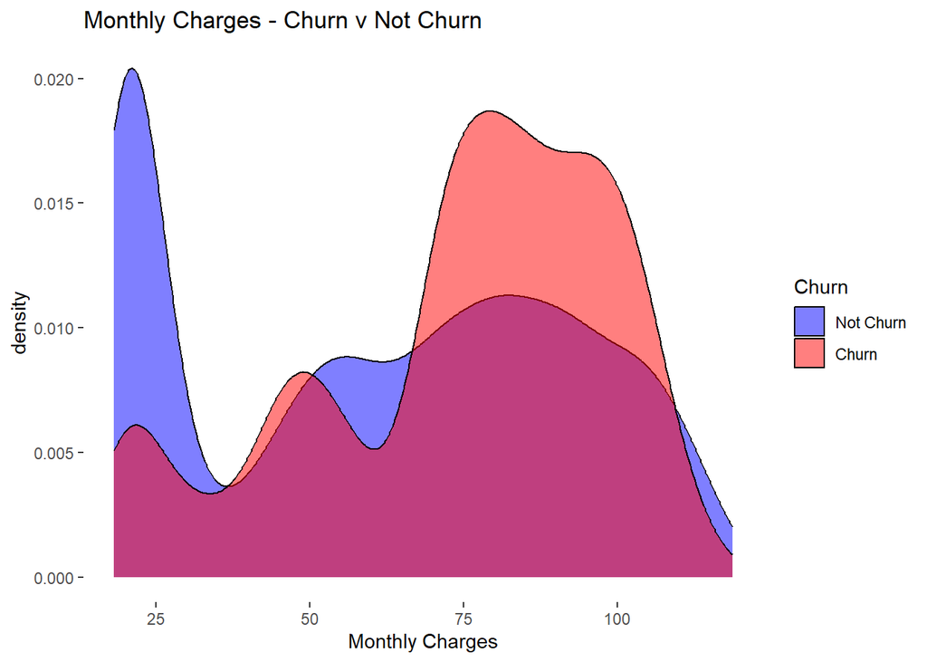

```r
plot_dat <- churn_data
plot_dat$Churn <- as.factor(plot_dat$Churn)

g_1 <- ggplot(plot_dat, aes(x = MonthlyCharges, fill = Churn)) +
  geom_density(alpha = 0.5) +
    theme_set(theme_bw(base_size = 22) ) +
  theme(panel.grid.major = element_blank(),
        panel.grid.minor = element_blank(),
        panel.border = element_blank(),
        panel.background = element_blank()) +
  labs(x = "Monthly Charges", title = "Monthly Charges - Churn v Not Churn",
       fill = "Churn") +
  scale_fill_manual(values = c("1" = "red", "0" = "blue"),
                    labels = c("1" = "Churn", "0" = "Not Churn"))
g_1
```

When value is under around 30 the customer is more likely to not churn, between 30 and 65 it can be either or, but when the charges are higher than that they are more likely to churn. It looks like it will be a helpful predictor.

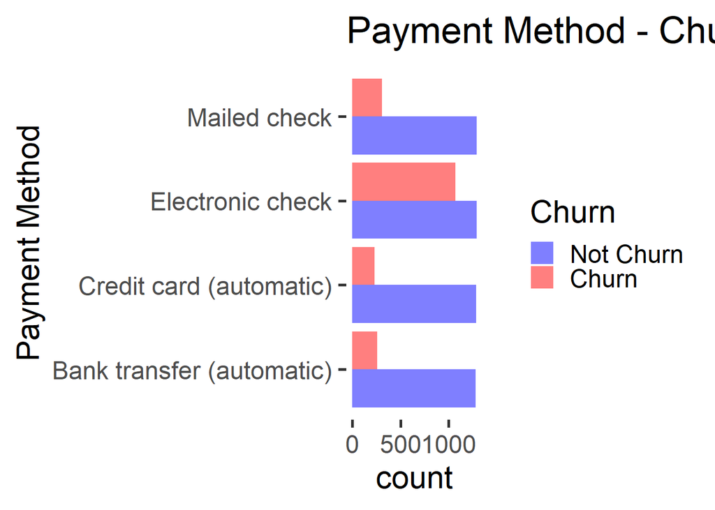

```r
g_2 <- ggplot(plot_dat, aes(x = PaymentMethod, fill = Churn)) +
  geom_bar(alpha = 0.5, position = "dodge") +
    theme_set(theme_bw(base_size = 14) ) +
  theme(panel.grid.major = element_blank(),
        panel.grid.minor = element_blank(),
        panel.border = element_blank(),
        panel.background = element_blank()) +
  labs(x = "Payment Method", title = "Payment Method - Churn v Not Churn",
       fill = "Churn") +
  scale_fill_manual(values = c("1" = "red", "0" = "blue"),
                    labels = c("1" = "Churn", "0" = "Not Churn")) +
  coord_flip()
g_2
```

The high values of Not Churn across all types may be due to the imbalance of data. However, we can see that those who use electronic checks are the ones that churn the most. This difference can hint that this will play a role.

- 2 - Fit a logistic regression model to the data. (Remember you can use `resp ~.,` to include all explanatory variables in the model) (2 Points)

```r
fit_1 <- glm(Churn ~ .,
             family=binomial(link='logit'),
             data= churn_data)
summary(fit_1)
```

```
Call:
glm(formula = Churn ~ ., family = binomial(link = "logit"), data = churn_data)

Coefficients: (7 not defined because of singularities)
                                       Estimate Std. Error z value Pr(>|z|)
(Intercept)                           1.165e+00  8.151e-01   1.430  0.15284
genderMale                           -2.183e-02  6.480e-02  -0.337  0.73619
SeniorCitizen                         2.168e-01  8.453e-02   2.564  0.01033 *
PartnerYes                           -3.840e-04  7.783e-02  -0.005  0.99606
DependentsYes                        -1.485e-01  8.973e-02  -1.655  0.09796 .
tenure                               -6.059e-02  6.236e-03  -9.716  < 2e-16 ***
PhoneServiceYes                       1.715e-01  6.487e-01   0.264  0.79153
MultipleLinesNo phone service                NA         NA      NA       NA
MultipleLinesYes                      4.484e-01  1.773e-01   2.530  0.01142 *
InternetServiceFiber optic            1.747e+00  7.981e-01   2.190  0.02855 *
InternetServiceNo                    -1.786e+00  8.073e-01  -2.213  0.02691 *
OnlineSecurityNo internet service            NA         NA      NA       NA
OnlineSecurityYes                    -2.054e-01  1.787e-01  -1.150  0.25031
OnlineBackupNo internet service              NA         NA      NA       NA
OnlineBackupYes                       2.604e-02  1.754e-01   0.148  0.88197
DeviceProtectionNo internet service          NA         NA      NA       NA
DeviceProtectionYes                   1.474e-01  1.764e-01   0.836  0.40339
TechSupportNo internet service               NA         NA      NA       NA
TechSupportYes                       -1.805e-01  1.806e-01  -0.999  0.31759
StreamingTVNo internet service               NA         NA      NA       NA
StreamingTVYes                        5.905e-01  3.263e-01   1.810  0.07035 .
StreamingMoviesNo internet service           NA         NA      NA       NA
StreamingMoviesYes                    5.993e-01  3.267e-01   1.834  0.06658 .
ContractOne year                     -6.608e-01  1.076e-01  -6.142 8.15e-10 ***
ContractTwo year                     -1.357e+00  1.764e-01  -7.691 1.46e-14 ***
PaperlessBillingYes                   3.424e-01  7.450e-02   4.596 4.31e-06 ***
PaymentMethodCredit card (automatic) -8.779e-02  1.141e-01  -0.770  0.44156
PaymentMethodElectronic check         3.045e-01  9.450e-02   3.222  0.00127 **
PaymentMethodMailed check            -5.759e-02  1.149e-01  -0.501  0.61627
MonthlyCharges                       -4.034e-02  3.176e-02  -1.270  0.20392
TotalCharges                          3.289e-04  7.063e-05   4.657 3.20e-06 ***
---
Signif. codes:  0 '***' 0.001 '**' 0.01 '*' 0.05 '.' 0.1 ' ' 1

(Dispersion parameter for binomial family taken to be 1)

    Null deviance: 8143.4  on 7031  degrees of freedom
Residual deviance: 5826.3  on 7008  degrees of freedom
AIC: 5874.3

Number of Fisher Scoring iterations: 6
```

- 3 - What features are significant in your logistic regression model? (1 Point)
- tenure (-ve)
- Contract (-ve)
- Paperless Billing (+ve)
- TotalCharges (+ve)
- 4 - What is the AIC of your logistic regression model? (1 Point)

AIC is 5874.3

- 5 - Add an interaction term to the logistic regression model? (1 Point)

```r
fit_2 <- glm(Churn ~ . + PaymentMethod*MultipleLines,
             family=binomial(link='logit'),
             data= churn_data)
summary(fit_2)
```

```
Call:
glm(formula = Churn ~ . + PaymentMethod * MultipleLines, family = binomial(link = "logit"),
    data = churn_data)

Coefficients: (7 not defined because of singularities)
                                                                     Estimate
(Intercept)                                                         1.543e+00
genderMale                                                         -2.230e-02
SeniorCitizen                                                       2.136e-01
PartnerYes                                                         -8.844e-03
DependentsYes                                                      -1.384e-01
tenure                                                             -6.167e-02
PhoneServiceYes                                                    -1.186e-01
MultipleLinesNo phone service                                              NA
MultipleLinesYes                                                    3.576e-01
InternetServiceFiber optic                                          1.798e+00
InternetServiceNo                                                  -1.860e+00
OnlineSecurityNo internet service                                          NA
OnlineSecurityYes                                                  -1.970e-01
OnlineBackupNo internet service                                            NA
OnlineBackupYes                                                     3.336e-02
DeviceProtectionNo internet service                                        NA
DeviceProtectionYes                                                 1.564e-01
TechSupportNo internet service                                             NA
TechSupportYes                                                     -1.692e-01
StreamingTVNo internet service                                             NA
StreamingTVYes                                                      5.981e-01
StreamingMoviesNo internet service                                         NA
StreamingMoviesYes                                                  6.019e-01
ContractOne year                                                   -6.522e-01
ContractTwo year                                                   -1.338e+00
PaperlessBillingYes                                                 3.369e-01
PaymentMethodCredit card (automatic)                               -1.458e-01
PaymentMethodElectronic check                                       2.171e-01
PaymentMethodMailed check                                           1.304e-02
MonthlyCharges                                                     -4.153e-02
TotalCharges                                                        3.362e-04
MultipleLinesNo phone service:PaymentMethodCredit card (automatic) -4.866e-01
MultipleLinesYes:PaymentMethodCredit card (automatic)               1.949e-01
MultipleLinesNo phone service:PaymentMethodElectronic check        -7.478e-02
```

[output cut: 112 more lines]

```
MultipleLinesYes:PaymentMethodCredit card (automatic)                0.4178
MultipleLinesNo phone service:PaymentMethodElectronic check          0.8307
MultipleLinesYes:PaymentMethodElectronic check                       0.3746
MultipleLinesNo phone service:PaymentMethodMailed check              0.0546 .
MultipleLinesYes:PaymentMethodMailed check                           0.7181
---
Signif. codes:  0 '***' 0.001 '**' 0.01 '*' 0.05 '.' 0.1 ' ' 1

(Dispersion parameter for binomial family taken to be 1)

    Null deviance: 8143.4  on 7031  degrees of freedom
Residual deviance: 5817.6  on 7002  degrees of freedom
AIC: 5877.6

Number of Fisher Scoring iterations: 6
```

- 6 - Does the addition of the interaction term increase or decrease the AIC? What is the new AIC for the model? (1 Point)

It increased the AIC to 5877.6

- 7 - Fit a lasso logistic regression model to the data. (1 Point)

```r
x_data <- churn_data
x_data[, c(5,18,19)] <- scale(churn_data[,c(5,18,19)])
x_vars <- model.matrix(Churn~., churn_data)[,-1]


set.seed(123)

lambda_seq <- 10^seq(4, -4, by = -.1)

cv.lasso <- cv.glmnet(x = x_vars,
                 y = churn_data$Churn,
                 alpha = 1,
                 family = "binomial",
                 lambda = lambda_seq, #
                 nfolds = 10)
best_lam <- cv.lasso$lambda.1se
best_lam
```

```
[1] 0.007943282
```

```r
lasso_fit_final <- glmnet(x = x_vars,
                    y = churn_data$Churn,
                    alpha = 1,
                    family = "binomial",
                    lambda = best_lam + 0.05)
coef(lasso_fit_final)
```

```
31 x 1 sparse Matrix of class "dgCMatrix"
                                                s0
(Intercept)                          -8.265699e-01
genderMale                            .
SeniorCitizen                         .
PartnerYes                            .
DependentsYes                         .
tenure                               -2.109702e-02
PhoneServiceYes                       .
MultipleLinesNo phone service         .
MultipleLinesYes                      .
InternetServiceFiber optic            7.161711e-01
InternetServiceNo                    -8.790466e-02
OnlineSecurityNo internet service    -2.849312e-15
OnlineSecurityYes                     .
OnlineBackupNo internet service      -7.671224e-16
OnlineBackupYes                       .
DeviceProtectionNo internet service  -3.287667e-16
DeviceProtectionYes                   .
TechSupportNo internet service        .
TechSupportYes                        .
StreamingTVNo internet service        .
StreamingTVYes                        .
StreamingMoviesNo internet service    .
StreamingMoviesYes                    .
ContractOne year                      .
ContractTwo year                     -1.083532e-01
PaperlessBillingYes                   .
PaymentMethodCredit card (automatic)  .
PaymentMethodElectronic check         3.131824e-01
PaymentMethodMailed check             .
MonthlyCharges                        .
TotalCharges                          .
```

- 8 - Which coefficients were non-zero in the lasso model? Were they positive or negative? What does this imply? (1 Point)
- tenure (-ve)
- InternetService Fiber optic (+ve)
- InternetService No (-ve)
- OnlineSecurity No internet service (-ve)
- OnlineBackup No internet service (-ve)
- DeviceProtection No internet service (-ve)
- Contract Two year (-ve)
- PaymentMethod Electronic check (+ve)

if positive increases probability of churn if negative decreases probability of churn

2 Points for analysis decisions and code quality.

Please submit an an R-markdown document with the answers, optionally you can submit an R-script with the code used for your analysis and a document answering the specific questions, you can use word, pdf etc.

Assignments can be submitted via Canvas or by email to mbarron2@nd.edu.